# Comparative analysis of Metaheuristics Algorithms to solve Optimization Problems

### 4.3 Step 3: Measure Fitness on Tuned Algorithms

```python
# Random Hill Climbing
algo_stats = []
t_start = time.time()*1000.0
best_state, best_fitness, curve_vals = mlrose.random_hill_climb(problem,max_attempts=10,restarts=3,curve=True,random_state=11)
t_stop = time.time()*1000.0
runtime = t_stop - t_start
algo_stats.append(["TSP", "RHC", best_state, best_fitness, 10, curve_vals.size, curve_vals, runtime])

# Genetic Algorithm
t_start = time.time()*1000.0
best_state, best_fitness, curve_vals = mlrose.genetic_alg(problem, max_attempts=1., pop_size=200,mutation_prob=0.25,curve=True,random_state=11)
t_stop = time.time()*1000.0
runtime = t_stop - t_start
algo_stats.append(["TSP", "GA", best_state, best_fitness, 10, curve_vals.size, curve_vals, runtime])


geomdecay = mlrose.GeomDecay(init_temp=10000.0, decay=0.0001, min_temp=1)
# geomdecay = mlrose.GeomDecay(init_temp=1000.0, decay=0.01, min_temp=1)

# Simulated Annealing
t_start = time.time()*1000.0
best_state, best_fitness, curve_vals = mlrose.simulated_annealing(problem,max_attempts=10,schedule=arithdecay,curve=True,random_state=11)
t_stop = time.time()*1000.0
runtime = t_stop - t_start
algo_stats.append(["TSP", "SA", best_state, best_fitness, 10, curve_vals.size, curve_vals, runtime])

# MIMIC
t_start = time.time()*1000.0
best_state, best_fitness, curve_vals = mlrose.mimic(problem,max_attempts=10,keep_pct=0.25,pop_size=400,curve=True,random_state=11)
t_stop = time.time()*1000.0
runtime = t_stop - t_start
algo_stats.append(["TSP", "MIMIC", best_state, best_fitness, 10, curve_vals.size, curve_vals, runtime])
```

```python
dfstats_TSP_Opt = pd.DataFrame(algo_stats, columns=['Problem', 'Algorithm', 'Best_State', 'Best_Fitness', 'Max_Attempts', 'Iterations', 'Fitness', 'Runtime'])
```

```python
dfstats_TSP_Opt.sort_values(['Best_Fitness', 'Iterations'], ascending=[False, True]).iloc[0]
```

```
Problem                                              TSP
Algorithm                                             GA
Best_State                      [2, 5, 1, 6, 3, 0, 4, 7]
Best_Fitness                                     33.4088
Max_Attempts                                          10
Iterations                                             2
Fitness         [33.408840000962066, 33.408840000962066]
Runtime                                          62.8687
Name: 1, dtype: object
```

```python
dfstats_TSP_Opt
```

|  | Problem | Algorithm | Best_State | Best_Fitness | Max_Attempts | Iterations | Fitness | Runtime |
| --- | --- | --- | --- | --- | --- | --- | --- | --- |
| 0 | TSP | RHC | [1, 6, 2, 5, 7, 3, 0, 4] | 33.073753 | 10 | 21 | [26.891483386175217, 27.352951983056318, 27.35... | 9.939453 |
| 1 | TSP | GA | [2, 5, 1, 6, 3, 0, 4, 7] | 33.408840 | 10 | 2 | [33.408840000962066, 33.408840000962066] | 62.868652 |
| 2 | TSP | SA | [4, 1, 6, 2, 5, 0, 3, 7] | 33.290067 | 10 | 21 | [27.492748851486766, 27.57466348470424, 26.612... | 1.984619 |
| 3 | TSP | MIMIC | [0, 3, 6, 1, 5, 2, 7, 4] | 33.408840 | 10 | 11 | [33.408840000962066, 33.408840000962066, 33.40... | 2126.421631 |

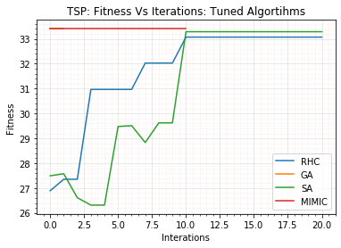

```python
for i in range(0, dfstats_TSP_Opt.shape[0]):
    plt.plot(dfstats_TSP_Opt.iloc[i]['Fitness'], label=dfstats_TSP_Opt.iloc[i]['Algorithm'])

plt.title('TSP: Fitness Vs Iterations: Tuned Algortihms')
plt.legend(loc='lower right')
plt.xlabel('Interations')
plt.ylabel('Fitness')
plt.minorticks_on()
plt.grid(b=True, which='major', color='k', linestyle='-', alpha=0.1)
plt.grid(b=True, which='minor', color='r', linestyle='-', alpha=0.05)
plt.show()
```

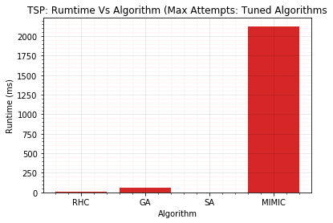

```python
for i in range(0, dfstats_TSP_Opt.shape[0]):
    plt.bar(dfstats_TSP_Opt['Algorithm'], dfstats_TSP_Opt['Runtime'])

plt.title('TSP: Rumtime Vs Algorithm (Max Attempts: Tuned Algorithms')
plt.xlabel('Algorithm')
plt.ylabel('Runtime (ms)')
plt.minorticks_on()
plt.grid(b=True, which='major', color='k', linestyle='-', alpha=0.1)
plt.grid(b=True, which='minor', color='r', linestyle='-', alpha=0.05)
```

Comparision with perfromance in Step 1:  
Fitness of *Genetic Algorithm* and *MIMIC* improved slightly with the algorithm tunning whereas it remained same for *Random Hill Climbing* and *Simulated Annealing*. After perfrmance tuning, *Genetic Algorithm* converged much quickly which also reduced the runtime.

### 3.4 Step 4: Measure Fitness of Tuned Algorithms on Increased Complexity

Complexity of model was increased by increasing the number of cities to 40.

```python
size=40
# Create list of city coordinates
coords_list = [(1, 1), (4, 2), (5, 2), (15, 4), (7, 4), (3, 6), (1, 10), (5, 3),
              (9, 1), (7, 2), (8, 2), (2, 14), (4, 4), (13, 6), (10, 5), (3, 14),
              (1, 1), (3, 12), (15, 2), (1, 4), (4, 4), (11, 11), (1, 5), (2, 11),
              (0, 7), (11, 2), (5, 3), (7, 14), (14, 4), (6, 6), (3, 4), (2, 2),
              (15, 15), (4, 12), (8, 0), (6, 4), (10, 2), (3, 6), (10, 5), (2, 3)]
```

```python
# Initialize fitness function object using coords_list
fitness = mlrose.TravellingSales(coords = coords_list)
```

```python
problem = mlrose.TSPOpt(length = size, fitness_fn = fitness, maximize = True)
```

```python
# Random Hill Climbing
algo_stats = []
t_start = time.time()*1000.0
best_state, best_fitness, curve_vals = mlrose.random_hill_climb(problem,restarts=3,curve=True,random_state=11)
t_stop = time.time()*1000.0
runtime = t_stop - t_start
algo_stats.append(["TSP", "RHC", best_state, best_fitness, 10, curve_vals.size, curve_vals, runtime])

# Genetic Algorithm
t_start = time.time()*1000.0
best_state, best_fitness, curve_vals = mlrose.genetic_alg(problem, pop_size=200,mutation_prob=0.1,curve=True,random_state=11)
t_stop = time.time()*1000.0
runtime = t_stop - t_start
algo_stats.append(["TSP", "GA", best_state, best_fitness, 10, curve_vals.size, curve_vals, runtime])


# Simulated Annealing
t_start = time.time()*1000.0
best_state, best_fitness, curve_vals = mlrose.simulated_annealing(problem,schedule=arithdecay,curve=True,random_state=11)
t_stop = time.time()*1000.0
runtime = t_stop - t_start
algo_stats.append(["TSP", "SA", best_state, best_fitness, 10, curve_vals.size, curve_vals, runtime])

# MIMIC
t_start = time.time()*1000.0
best_state, best_fitness, curve_vals = mlrose.mimic(problem,keep_pct=0.25,pop_size=400,curve=True,random_state=11)
t_stop = time.time()*1000.0
runtime = t_stop - t_start
algo_stats.append(["TSP", "MIMIC", best_state, best_fitness, 10, curve_vals.size, curve_vals, runtime])
```

```python
dfstats_TSP_Opt_Cmplx = pd.DataFrame(algo_stats, columns=['Problem', 'Algorithm', 'Best_State', 'Best_Fitness', 'Max_Attempts', 'Iterations', 'Fitness', 'Runtime'])
```

```python
dfstats_TSP_Opt_Cmplx.sort_values(['Best_Fitness', 'Iterations'], ascending=[False, True]).iloc[0]
```

```
Problem                                                       TSP
Algorithm                                                      SA
Best_State      [16, 27, 34, 23, 4, 8, 22, 38, 24, 9, 35, 30, ...
Best_Fitness                                              403.583
Max_Attempts                                                   10
Iterations                                                    269
Fitness         [306.4765083453617, 305.96201038187183, 315.68...
Runtime                                                   32.9114
Name: 2, dtype: object
```

```python
dfstats_TSP_Opt_Cmplx
```

|  | Problem | Algorithm | Best_State | Best_Fitness | Max_Attempts | Iterations | Fitness | Runtime |
| --- | --- | --- | --- | --- | --- | --- | --- | --- |
| 0 | TSP | RHC | [38, 33, 7, 10, 27, 16, 3, 22, 18, 6, 31, 29, ... | 375.664147 | 10 | 52 | [332.9226370930129, 334.54284554529534, 334.54... | 24.938721 |
| 1 | TSP | GA | [6, 26, 28, 23, 13, 39, 35, 33, 8, 5, 10, 15, ... | 386.139282 | 10 | 28 | [357.87950934801, 357.98847463809807, 357.9884... | 1346.914795 |
| 2 | TSP | SA | [16, 27, 34, 23, 4, 8, 22, 38, 24, 9, 35, 30, ... | 403.583004 | 10 | 269 | [306.4765083453617, 305.96201038187183, 315.68... | 32.911377 |
| 3 | TSP | MIMIC | [26, 27, 16, 36, 33, 18, 19, 28, 1, 29, 30, 38... | 386.339256 | 10 | 20 | [361.73056991353934, 364.812263874038, 371.544... | 30997.762939 |

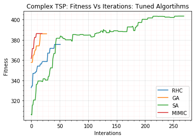

```python
for i in range(0, dfstats_TSP_Opt.shape[0]):
    plt.plot(dfstats_TSP_Opt_Cmplx.iloc[i]['Fitness'], label=dfstats_TSP_Opt_Cmplx.iloc[i]['Algorithm'])

plt.title('Complex TSP: Fitness Vs Iterations: Tuned Algortihms')
plt.legend(loc='lower right')
plt.xlabel('Interations')
plt.ylabel('Fitness')
plt.minorticks_on()
plt.grid(b=True, which='major', color='k', linestyle='-', alpha=0.1)
plt.grid(b=True, which='minor', color='r', linestyle='-', alpha=0.05)
plt.show()
```

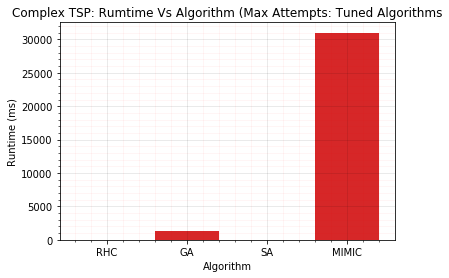

```python
for i in range(0, dfstats_TSP_Opt.shape[0]):
    plt.bar(dfstats_TSP_Opt_Cmplx['Algorithm'], dfstats_TSP_Opt_Cmplx['Runtime'])

plt.title('Complex TSP: Rumtime Vs Algorithm (Max Attempts: Tuned Algorithms')
plt.xlabel('Algorithm')
plt.ylabel('Runtime (ms)')
plt.minorticks_on()
plt.grid(b=True, which='major', color='k', linestyle='-', alpha=0.1)
plt.grid(b=True, which='minor', color='r', linestyle='-', alpha=0.05)
```

Comparision with perfromance in Step 2: Perfromance of *Simulated Annealing* increased with increase in the complexity of the problem. Other trends such as runtime and iteration required to converge remained consistent.

**Strength of Simulated Annealing:** Travelling salesman problem is a NP-Hard problem and the fitness landscape of the choosen problem has many local optima. Although Simulated Annealing is greedy algorithm unlike Random Hill Climbing it accepts worse solutions by slowly decreasing the probability of accepting such bad solutions in search space. If the search space is large it find the global optima. In this choosen problem Simulated Annealing performed as good as MIMIC and Genetic Algorithm because of its ability to get out of local optima by randomizing search space. Simulated annealing is extremely fast as compared Genetic Algorithm and MIMIC.

Weakness of Simulated Annealing: If the underlying structure is complex, Simulated Annealing may get stuck in the local optima. As it accepts worst solutions when temperature is high, we might see poor convergance rate.

## 5 References

[1] https://mlrose.readthedocs.io/en/stable/source/tutorial1.html  
[2] https://en.wikipedia.org/wiki/Optimization_problem  
[3] https://en.wikipedia.org/wiki/Knapsack_problem  
[4] https://mlrose.readthedocs.io/en/stable/source/tutorial1.html  
[5] https://mlrose.readthedocs.io/en/stable/source/tutorial2.html  
[6] https://en.wikipedia.org/wiki/Hill_climbing  
[7] https://en.wikipedia.org/wiki/Simulated_annealing  
[8] https://en.wikipedia.org/wiki/Genetic_algorithm  
[9] https://www.cc.gatech.edu/~isbell/papers/isbell-mimic-nips-1997.pdf  
[10] https://mlrose.readthedocs.io/en/stable/source/fitness.html#mlrose.fitness.Knapsack  
[11] https://mlrose.readthedocs.io/en/stable/source/tutorial1.html  
[12] https://mlrose.readthedocs.io/en/stable/source/tutorial2.html#define-a-fitness-function-object